# Outliers and Impact on Machine Learning

### Which Machine Learning Models are sensitive to outliers i.e getting impacted by outliers?

1. Naive Bayes Classifier ---- Not Sensitive to Outliers
2. SVM ----------------------- Not Sensitive to Outliers
3. Linear Regression --------- Sensitive to Outliers
4. Logistic Regression ------- Sensitive
5. Decision Tree Regressor or Classifier ---- Not Sensitive
6. Ensemble (Random Forest, XGBoost, Gradient Boosting) ---- Not Sensitive
7. KNN ----------------------- Not Sensitive
8. Kmeans -------------------- Sensitive
9. Hierarchial ---------------- Sensitive
10. PCA/LDA ------------------ Sensitive (very sensitive so remove the outliers)
11. Neural Networks ---------- Sensitive
12. DBSCAN ------------------- Sensitive

Learning the maths of machine learning algorithms will help you understand them. The Kmeans for e.g. uses Euclidean distance so it will be sensitive to the outliers

All unsupervised learning will be Sensitive to Outliers

If you need say to do a credit card fraud where the outliers are very important and should not be removed, use the algorithm that is not sensitive to outliers

```python
# import libraries
import pandas as pd
```

```python
# import dataset
df = pd.read_csv('titanic.csv')
df.head()
```

|  | PassengerId | Survived | Pclass | Name | Sex | Age | SibSp | Parch | Ticket | Fare | Cabin | Embarked |
| --- | --- | --- | --- | --- | --- | --- | --- | --- | --- | --- | --- | --- |
| 0 | 1 | 0 | 3 | Braund, Mr. Owen Harris | male | 22.0 | 1 | 0 | A/5 21171 | 7.2500 | NaN | S |
| 1 | 2 | 1 | 1 | Cumings, Mrs. John Bradley (Florence Briggs Th... | female | 38.0 | 1 | 0 | PC 17599 | 71.2833 | C85 | C |
| 2 | 3 | 1 | 3 | Heikkinen, Miss. Laina | female | 26.0 | 0 | 0 | STON/O2. 3101282 | 7.9250 | NaN | S |
| 3 | 4 | 1 | 1 | Futrelle, Mrs. Jacques Heath (Lily May Peel) | female | 35.0 | 1 | 0 | 113803 | 53.1000 | C123 | S |
| 4 | 5 | 0 | 3 | Allen, Mr. William Henry | male | 35.0 | 0 | 0 | 373450 | 8.0500 | NaN | S |

```python
# checking Age column for null value
df['Age'].isnull().sum()
```

```
177
```

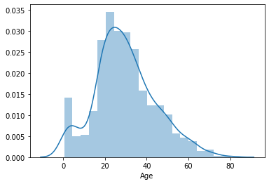

```python
# To do the distribution in terms of Age
import seaborn as sns
sns.distplot(df.Age.dropna())  # df['Age'].dropna()
```

This looks like a normal distribution. Whenever we have a normal distribution, the technique we'll be using is estimate outliers-Extreme value analysis is applied to find out the IQR. The extra points outside the curve isn't a concern.

If your dataset is skewed, then we use different techniques.

Let's create outlier by filling NA with 100 so we can demonstrate how to remove it

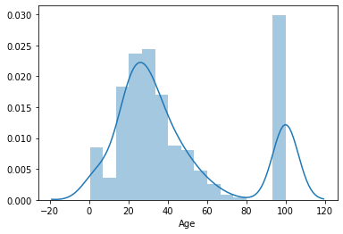

```python
# let's create outlier by filling null values with 100 so we can demonstrate how to remove it
sns.distplot(df.Age.fillna(100))
```

### If Data Is Normally Distributed

Gaussian/Normal Distributed

We will use standard distribution.

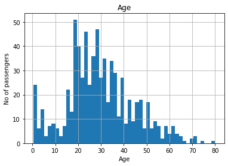

```python
### Let's check if there is an outlier, without using the fillna to create artificial outliers
figure = df.Age.hist(bins=50)
figure.set_title('Age')
figure.set_xlabel('Age')
figure.set_ylabel('No of passengers')
```

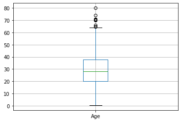

```python
### to find the outliers
figure = df.boxplot(column='Age')
```

The circles are outliers

```python
df['Age'].describe()   # notice that we did not drop nan values
```

```
count    714.000000
mean      29.699118
std       14.526497
min        0.420000
25%       20.125000
50%       28.000000
75%       38.000000
max       80.000000
Name: Age, dtype: float64
```

We can see that the max value is 80, 25 percentile is 20.12, 50 percentile is 28, 75 percentile is 38.

#### Assuming Age follows a Gaussian/Normal Distribution, we will calculate the boundaries which differentiates the outliers.

The mean, 3-Std Dev is considered.

99% of data is present within the 3-Std Dev

```python
### make upper boundary
upper_boundary = df['Age'].mean() + 3 * df['Age'].std()  # 3 *: represents 3 Std Dev.
lower_boundary = df['Age'].mean() - 3 * df['Age'].std()  # 3 *: represents 3 Std Dev.
print(lower_boundary), print(upper_boundary), print(df['Age'].mean())
```

```
-13.88037434994331
73.27860964406095
29.69911764705882
```

```
(None, None, None)
```

Note: In Age, the value cannot be negative so -13.88 isn't quite correct. We will only remove the values greater than 73 (upper_boundary)

### If Features Are Skewed We Use the below Technique

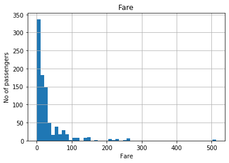

```python
### Let's check if there is an outlier, without using the fillna to create artificial outliers
figure = df.Fare.hist(bins=50)
figure.set_title('Fare')
figure.set_xlabel('Fare')
figure.set_ylabel('No of passengers')
```

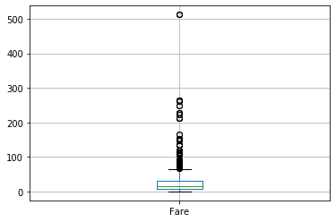

```python
# boxplot
df.boxplot(column='Fare')
```

You can see that there is a hugh amount of outliers (the circles).

```python
df['Fare'].describe()
```

```
count    891.000000
mean      32.204208
std       49.693429
min        0.000000
25%        7.910400
50%       14.454200
75%       31.000000
max      512.329200
Name: Fare, dtype: float64
```

**Notice the difference between the 75% and max values. it's hugh, indicating outliers.**

#### Compute the IQR

```python
IQR = df.Fare.quantile(0.75) - df.Fare.quantile(0.25)
IQR
```

```
23.0896
```

#### Calculate the boundaries

```python
### calculating the lower and upper bridge
lower_bridge = df['Fare'].quantile(0.25) - (IQR*1.5)
upper_bridge = df['Fare'].quantile(0.75) + (IQR*1.5)
print(lower_bridge), print(upper_bridge)
```

```
-26.724
65.6344
```

```
(None, None)
```

#### Calculate the Extreme boundaries

```python
### Extreme Outliers
lower_bridge = df['Fare'].quantile(0.25) - (IQR*3)
upper_bridge = df['Fare'].quantile(0.75) + (IQR*3)
print(lower_bridge), print(upper_bridge)
```

```
-61.358399999999996
100.2688
```

```
(None, None)
```

In the right skewed data of Fare, the max is 512 and we have extreme outlier as 100 so using extreme outlier is better than using 1.5*IQR for skewed data. The Fare cannot be negative so we will not use the -61 value.

If it's left skewed, you take the left value of the extreme outlier result.

### Removing Outliers

- If the dataset does not have a lot of observations, you can replace them with a value instead of removing them.
- whereever you have values greater than 73, replace those outliers with the upper_boundary value of 73
- For Fare, replace the outliers with upper boundary value of 100

```python
data = df.copy()
```

```python
# whereever you have values greater than 73, replace those outliers with the upper_boundary value of 73
data.loc[data['Age']>=73, 'Age']=73
```

```python
# for Fare, replace the outliers with upper boundary value of 100
data.loc[data['Fare']>=100, 'Fare'] = 100
```

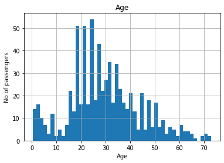

```python
figure = data.Age.hist(bins=50)
figure.set_title('Age')
figure.set_xlabel('Age')
figure.set_ylabel('No of passengers')
```

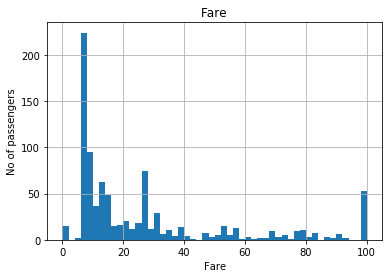

```python
figure = data.Fare.hist(bins=50)
figure.set_title('Fare')
figure.set_xlabel('Fare')
figure.set_ylabel('No of passengers')
```

### Creating a model

```python
from sklearn.model_selection import train_test_split
X_train, X_test, y_train, y_test = train_test_split(data[['Age','Fare']].fillna(0), data['Survived'], test_size=0.3, random_state=21)
```

```python
### Applying Logistic Regression
from sklearn.linear_model import LogisticRegression
classifier = LogisticRegression()
classifier.fit(X_train, y_train)
y_pred = classifier.predict(X_test)
y_pred1 = classifier.predict_proba(X_test)

from sklearn.metrics import accuracy_score, roc_auc_score
print('Accuracy score: {}'.format(accuracy_score(y_test, y_pred)))
print('ROC AUC score: {}'.format(roc_auc_score(y_test, y_pred1[:,1])))
```

```
Accuracy score: 0.6902985074626866
ROC AUC score: 0.738927265339293
```

#### Trying another algorithm

```python
### RandomForestClassifier. Use RandomForestRegressor if dependent variable is not categorical
from sklearn.ensemble import RandomForestClassifier
classifier = RandomForestClassifier()
classifier.fit(X_train, y_train)
y_pred = classifier.predict(X_test)
y_pred1 = classifier.predict_proba(X_test)

from sklearn.metrics import accuracy_score, roc_auc_score
print('Accuracy score: {}'.format(accuracy_score(y_test, y_pred)))
print('ROC AUC score: {}'.format(roc_auc_score(y_test, y_pred1[:,1])))
```

```
Accuracy score: 0.6902985074626866
ROC AUC score: 0.7273756312764845
```